# CreditCardUserChurnersTuning

```python
# Libraries to help with reading and manipulating data
import numpy as np
import pandas as pd
# Libraries to help with data visualization
import matplotlib.pyplot as plt
import seaborn as sns
# Libraries to tune model, get different metric scores, and split data
from sklearn.model_selection import GridSearchCV
from sklearn.model_selection import train_test_split, StratifiedKFold, cross_val_score
from sklearn.metrics import accuracy_score,precision_score,recall_score
from sklearn import metrics
# Library to impute missing values
from sklearn.impute import KNNImputer
# Library to build a logistic regression model
from sklearn.linear_model import LogisticRegression
# Library to supress the warning
import warnings
warnings.filterwarnings('ignore')
import timeit
```

```python
BankChurners = pd.read_csv('BankChurners.csv')
```

```python
#Creating array to capture execution times of each cell
elapsed_arr=[]
```

```python
# copying data to another varaible to avoid any changes to original data
data = BankChurners.copy()
```

```python
data.head()
```

|  | CLIENTNUM | Attrition_Flag | Customer_Age | Gender | Dependent_count | Education_Level | Marital_Status | Income_Category | Card_Category | Months_on_book | ... | Contacts_Count_12_mon | Credit_Limit | Total_Revolving_Bal | Avg_Open_To_Buy | Total_Amt_Chng_Q4_Q1 | Total_Trans_Amt | Total_Trans_Ct | Total_Ct_Chng_Q4_Q1 | Avg_Utilization_Ratio | Unnamed: 21 |
| --- | --- | --- | --- | --- | --- | --- | --- | --- | --- | --- | --- | --- | --- | --- | --- | --- | --- | --- | --- | --- | --- |
| 0 | 768805383 | Existing Customer | 45 | M | 3 | High School | Married | $60K - $80K | Blue | 39 | ... | 3 | 12691.0 | 777 | 11914.0 | 1.335 | 1144 | 42 | 1.625 | 0.061 | NaN |
| 1 | 818770008 | Existing Customer | 49 | F | 5 | Graduate | Single | Less than $40K | Blue | 44 | ... | 2 | 8256.0 | 864 | 7392.0 | 1.541 | 1291 | 33 | 3.714 | 0.105 | NaN |
| 2 | 713982108 | Existing Customer | 51 | M | 3 | Graduate | Married | $80K - $120K | Blue | 36 | ... | 0 | 3418.0 | 0 | 3418.0 | 2.594 | 1887 | 20 | 2.333 | 0.000 | NaN |
| 3 | 769911858 | Existing Customer | 40 | F | 4 | High School | Unknown | Less than $40K | Blue | 34 | ... | 1 | 3313.0 | 2517 | 796.0 | 1.405 | 1171 | 20 | 2.333 | 0.760 | NaN |
| 4 | 709106358 | Existing Customer | 40 | M | 3 | Uneducated | Married | $60K - $80K | Blue | 21 | ... | 0 | 4716.0 | 0 | 4716.0 | 2.175 | 816 | 28 | 2.500 | 0.000 | NaN |

5 rows × 22 columns

```python
data.tail()
```

|  | CLIENTNUM | Attrition_Flag | Customer_Age | Gender | Dependent_count | Education_Level | Marital_Status | Income_Category | Card_Category | Months_on_book | ... | Contacts_Count_12_mon | Credit_Limit | Total_Revolving_Bal | Avg_Open_To_Buy | Total_Amt_Chng_Q4_Q1 | Total_Trans_Amt | Total_Trans_Ct | Total_Ct_Chng_Q4_Q1 | Avg_Utilization_Ratio | Unnamed: 21 |
| --- | --- | --- | --- | --- | --- | --- | --- | --- | --- | --- | --- | --- | --- | --- | --- | --- | --- | --- | --- | --- | --- |
| 10122 | 772366833 | Existing Customer | 50 | M | 2 | Graduate | Single | $40K - $60K | Blue | 40 | ... | 3 | 4003.0 | 1851 | 2152.0 | 0.703 | 15476 | 117 | 0.857 | 0.462 | NaN |
| 10123 | 710638233 | Attrited Customer | 41 | M | 2 | Unknown | Divorced | $40K - $60K | Blue | 25 | ... | 3 | 4277.0 | 2186 | 2091.0 | 0.804 | 8764 | 69 | 0.683 | 0.511 | NaN |
| 10124 | 716506083 | Attrited Customer | 44 | F | 1 | High School | Married | Less than $40K | Blue | 36 | ... | 4 | 5409.0 | 0 | 5409.0 | 0.819 | 10291 | 60 | 0.818 | 0.000 | NaN |
| 10125 | 717406983 | Attrited Customer | 30 | M | 2 | Graduate | Unknown | $40K - $60K | Blue | 36 | ... | 3 | 5281.0 | 0 | 5281.0 | 0.535 | 8395 | 62 | 0.722 | 0.000 | NaN |
| 10126 | 714337233 | Attrited Customer | 43 | F | 2 | Graduate | Married | Less than $40K | Silver | 25 | ... | 4 | 10388.0 | 1961 | 8427.0 | 0.703 | 10294 | 61 | 0.649 | 0.189 | NaN |

5 rows × 22 columns

```python
data.shape
```

```
(10127, 22)
```

```python
data.info()
```

```
<class 'pandas.core.frame.DataFrame'>
RangeIndex: 10127 entries, 0 to 10126
Data columns (total 22 columns):
 #   Column                    Non-Null Count  Dtype
---  ------                    --------------  -----
 0   CLIENTNUM                 10127 non-null  int64
 1   Attrition_Flag            10127 non-null  object
 2   Customer_Age              10127 non-null  int64
 3   Gender                    10127 non-null  object
 4   Dependent_count           10127 non-null  int64
 5   Education_Level           10127 non-null  object
 6   Marital_Status            10127 non-null  object
 7   Income_Category           10127 non-null  object
 8   Card_Category             10127 non-null  object
 9   Months_on_book            10127 non-null  int64
 10  Total_Relationship_Count  10127 non-null  int64
 11  Months_Inactive_12_mon    10127 non-null  int64
 12  Contacts_Count_12_mon     10127 non-null  int64
 13  Credit_Limit              10127 non-null  float64
 14  Total_Revolving_Bal       10127 non-null  int64
 15  Avg_Open_To_Buy           10127 non-null  float64
 16  Total_Amt_Chng_Q4_Q1      10127 non-null  float64
 17  Total_Trans_Amt           10127 non-null  int64
 18  Total_Trans_Ct            10127 non-null  int64
 19  Total_Ct_Chng_Q4_Q1       10127 non-null  float64
 20  Avg_Utilization_Ratio     10127 non-null  float64
 21  Unnamed: 21               0 non-null      float64
dtypes: float64(6), int64(10), object(6)
memory usage: 1.7+ MB
```

**Check the percentage of missing and unique values in each column**

```python
pd.DataFrame(data={'% of Missing Values':round(data.isnull().sum()/data.isnull().count()*100,2)}).sort_values(by='% of Missing Values',ascending=False)
```

|  | % of Missing Values |
| --- | --- |
| Unnamed: 21 | 100.0 |
| Attrition_Flag | 0.0 |
| Avg_Utilization_Ratio | 0.0 |
| Total_Ct_Chng_Q4_Q1 | 0.0 |
| Total_Trans_Ct | 0.0 |
| Total_Trans_Amt | 0.0 |
| Total_Amt_Chng_Q4_Q1 | 0.0 |
| Avg_Open_To_Buy | 0.0 |
| Total_Revolving_Bal | 0.0 |
| Credit_Limit | 0.0 |
| Contacts_Count_12_mon | 0.0 |
| CLIENTNUM | 0.0 |
| Total_Relationship_Count | 0.0 |
| Months_on_book | 0.0 |
| Card_Category | 0.0 |
| Income_Category | 0.0 |
| Marital_Status | 0.0 |
| Education_Level | 0.0 |
| Dependent_count | 0.0 |
| Gender | 0.0 |
| Customer_Age | 0.0 |
| Months_Inactive_12_mon | 0.0 |

- like mentioned above Unnamed has all null values so can be dropped
- rest all columns have values

```python
data.drop(['Unnamed: 21'],axis=1,inplace=True)
```

```python
data.nunique()
```

```
CLIENTNUM                   10127
Attrition_Flag                  2
Customer_Age                   45
Gender                          2
Dependent_count                 6
Education_Level                 7
Marital_Status                  4
Income_Category                 6
Card_Category                   4
Months_on_book                 44
Total_Relationship_Count        6
Months_Inactive_12_mon          7
Contacts_Count_12_mon           7
Credit_Limit                 6205
Total_Revolving_Bal          1974
Avg_Open_To_Buy              6813
Total_Amt_Chng_Q4_Q1         1158
Total_Trans_Amt              5033
Total_Trans_Ct                126
Total_Ct_Chng_Q4_Q1           830
Avg_Utilization_Ratio         964
dtype: int64
```

- since CLIENTNUM is an ID and unique for every record it can be dropped as it doesnt add any value to analysis

```python
data.drop(['CLIENTNUM'],axis=1,inplace=True)
```

- Since the below columns have less unique values they can be candidate for converted to category. Attrition_Flag,Gender,Education_Level,Marital_Status,Income_Category,Card_Category
- Finding the value_counts for each category value

```python
cat_cols=['Attrition_Flag','Gender','Education_Level','Marital_Status',
          'Income_Category','Card_Category']
for column in cat_cols:
    print(data[column].value_counts())
    print('-'*30)
```

```
Existing Customer    8500
Attrited Customer    1627
Name: Attrition_Flag, dtype: int64
------------------------------
F    5358
M    4769
Name: Gender, dtype: int64
------------------------------
Graduate         3128
High School      2013
Unknown          1519
Uneducated       1487
College          1013
Post-Graduate     516
Doctorate         451
Name: Education_Level, dtype: int64
------------------------------
Married     4687
Single      3943
Unknown      749
Divorced     748
Name: Marital_Status, dtype: int64
------------------------------
Less than $40K    3561
$40K - $60K       1790
$80K - $120K      1535
$60K - $80K       1402
Unknown           1112
$120K +            727
Name: Income_Category, dtype: int64
------------------------------
Blue        9436
Silver       555
Gold         116
Platinum      20
Name: Card_Category, dtype: int64
------------------------------
```

```python
data["Attrition_Flag"] = data["Attrition_Flag"].astype("category")
data["Gender"] = data["Gender"].astype("category")
data["Education_Level"] = data["Education_Level"].astype("category")
data["Marital_Status"] = data["Marital_Status"].astype("category")
data["Income_Category"] = data["Income_Category"].astype("category")
data["Card_Category"] = pd.Categorical(data["Card_Category"].astype("category"),['Blue','Silver','Gold','Platinum'],ordered=True)
```

### Summary of the dataset.

```python
data.describe().T
```

|  | count | mean | std | min | 25% | 50% | 75% | max |
| --- | --- | --- | --- | --- | --- | --- | --- | --- |
| Customer_Age | 10127.0 | 46.325960 | 8.016814 | 26.0 | 41.000 | 46.000 | 52.000 | 73.000 |
| Dependent_count | 10127.0 | 2.346203 | 1.298908 | 0.0 | 1.000 | 2.000 | 3.000 | 5.000 |
| Months_on_book | 10127.0 | 35.928409 | 7.986416 | 13.0 | 31.000 | 36.000 | 40.000 | 56.000 |
| Total_Relationship_Count | 10127.0 | 3.812580 | 1.554408 | 1.0 | 3.000 | 4.000 | 5.000 | 6.000 |
| Months_Inactive_12_mon | 10127.0 | 2.341167 | 1.010622 | 0.0 | 2.000 | 2.000 | 3.000 | 6.000 |
| Contacts_Count_12_mon | 10127.0 | 2.455317 | 1.106225 | 0.0 | 2.000 | 2.000 | 3.000 | 6.000 |
| Credit_Limit | 10127.0 | 8631.953698 | 9088.776650 | 1438.3 | 2555.000 | 4549.000 | 11067.500 | 34516.000 |
| Total_Revolving_Bal | 10127.0 | 1162.814061 | 814.987335 | 0.0 | 359.000 | 1276.000 | 1784.000 | 2517.000 |
| Avg_Open_To_Buy | 10127.0 | 7469.139637 | 9090.685324 | 3.0 | 1324.500 | 3474.000 | 9859.000 | 34516.000 |
| Total_Amt_Chng_Q4_Q1 | 10127.0 | 0.759941 | 0.219207 | 0.0 | 0.631 | 0.736 | 0.859 | 3.397 |
| Total_Trans_Amt | 10127.0 | 4404.086304 | 3397.129254 | 510.0 | 2155.500 | 3899.000 | 4741.000 | 18484.000 |
| Total_Trans_Ct | 10127.0 | 64.858695 | 23.472570 | 10.0 | 45.000 | 67.000 | 81.000 | 139.000 |
| Total_Ct_Chng_Q4_Q1 | 10127.0 | 0.712222 | 0.238086 | 0.0 | 0.582 | 0.702 | 0.818 | 3.714 |
| Avg_Utilization_Ratio | 10127.0 | 0.274894 | 0.275691 | 0.0 | 0.023 | 0.176 | 0.503 | 0.999 |

**Observations-**

- `Customer_Age:` Mean is around 46 and range is from 26 to 73. Which means mostly its younger generation that uses credit cards
- `Avg_Utilization_Ratio:` mean is 0.27 which is quite low. meaning people are utilizing only 25% of their credit limit
- `Credit_Limit:` mean is 8600. min max range is huge. Maybe more credit limit should be given to encourage people to spend more
- Most of the other fields are fairly normally distributed it seems

## EDA

### Univariate analysis

```python
# While doing uni-variate analysis of numerical variables we want to study their central tendency
# and dispersion.
# Let us write a function that will help us create boxplot and histogram for any input numerical
# variable.
# This function takes the numerical column as the input and returns the boxplots
# and histograms for the variable.
# Let us see if this help us write faster and cleaner code.
def histogram_boxplot(feature, figsize=(15,10), bins = None):
    """ Boxplot and histogram combined
    feature: 1-d feature array
    figsize: size of fig (default (9,8))
    bins: number of bins (default None / auto)
    """
    f2, (ax_box2, ax_hist2) = plt.subplots(nrows = 2, # Number of rows of the subplot grid= 2
                                           sharex = True, # x-axis will be shared among all subplots
                                           gridspec_kw = {"height_ratios": (.25, .75)},
                                           figsize = figsize
                                           ) # creating the 2 subplots
    sns.boxplot(feature, ax=ax_box2, showmeans=True, color='violet') # boxplot will be created and a star will indicate the mean value of the column
    sns.distplot(feature, kde=F, ax=ax_hist2, bins=bins,color = 'orange') if bins else sns.distplot(feature, kde=False, ax=ax_hist2,color='tab:cyan') # For histogram
    ax_hist2.axvline(np.mean(feature), color='purple', linestyle='--') # Add mean to the histogram
    ax_hist2.axvline(np.median(feature), color='black', linestyle='-') # Add median to the histogram
```

### Observations on Customer_Age

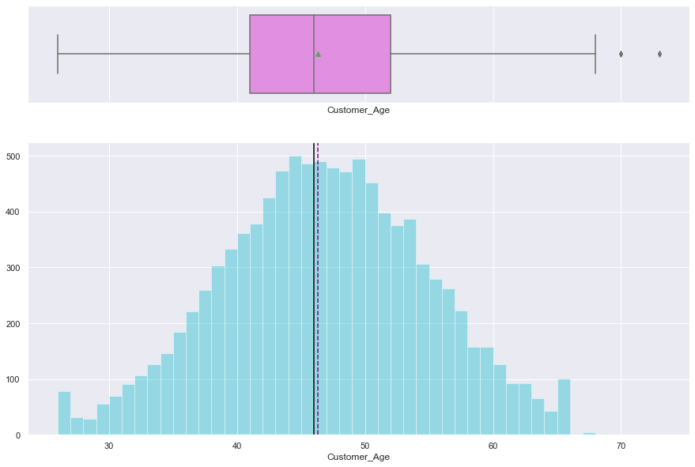

```python
histogram_boxplot(data['Customer_Age'])
```

- Age is normally distributed
- there are 2 outliers.lets investigate more on them

```python
data[data['Customer_Age']>60].Customer_Age.value_counts()
```

```
65    101
62     93
61     93
63     65
64     43
67      4
68      2
66      2
73      1
70      1
Name: Customer_Age, dtype: int64
```

- since these outliers are not too far from standard deviations I would keep them

### Observations on Months_on_book

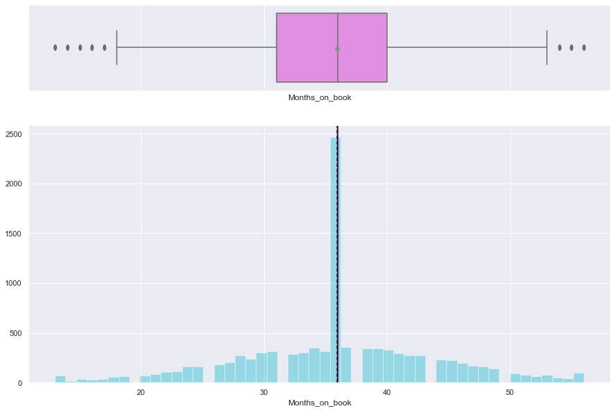

```python
histogram_boxplot(data['Months_on_book'])
```

- Months_on_book is normally distributed
- outliers are in close vicinity so ill keep them

### Observations on Credit_Limit

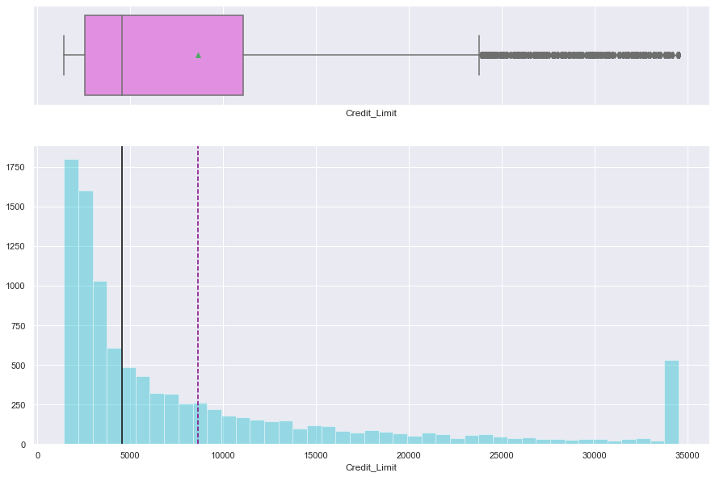

```python
histogram_boxplot(data['Credit_Limit'])
```

- Credit_limit is right skewed
- all the outliers as per box plot are close to each other so i wll keep them

### Observations on Total_Revolving_Bal

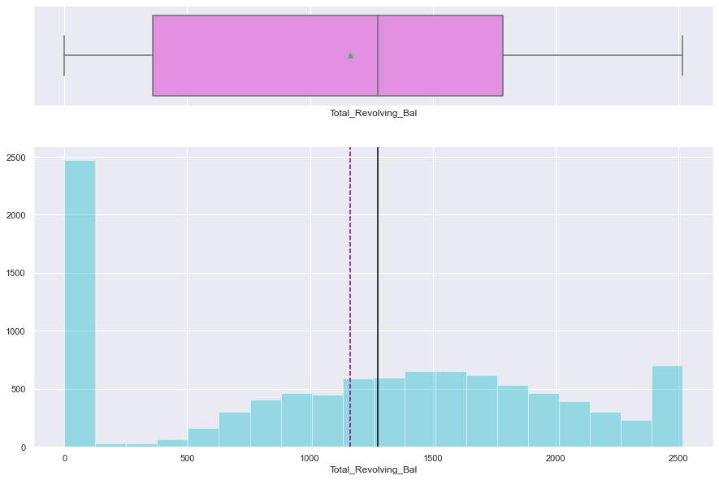

```python
histogram_boxplot(data['Total_Revolving_Bal'])
```

- Total_Revolving_bal is not normally distributed
- There are no outliers

### Observations on Avg_Open_To_Buy

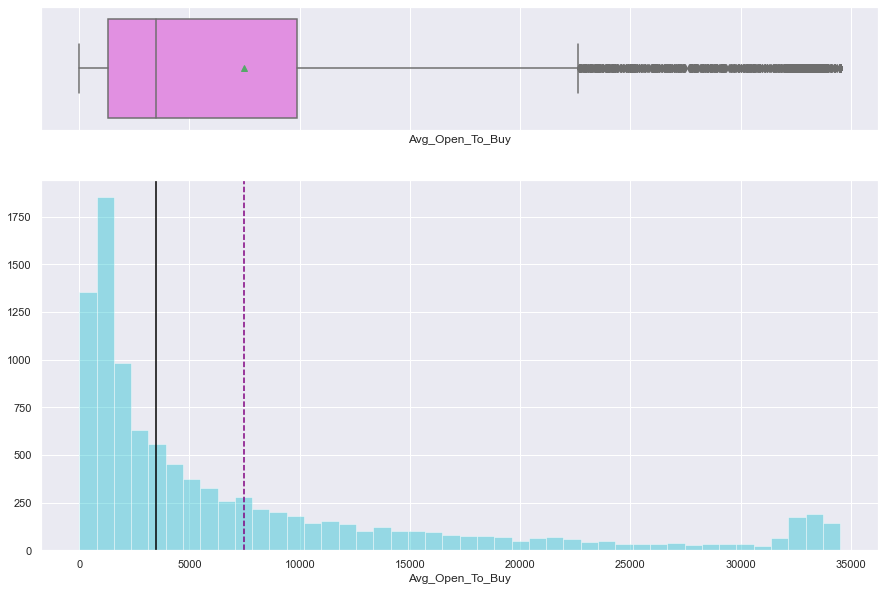

```python
histogram_boxplot(data['Avg_Open_To_Buy'])
```

- Avg_Open_To_Buy is skewed to the right
- There are many outliers but we can keep them since they are close to each other and within Standard deviation

### Observations on Total_Amt_Chng_Q4_Q1

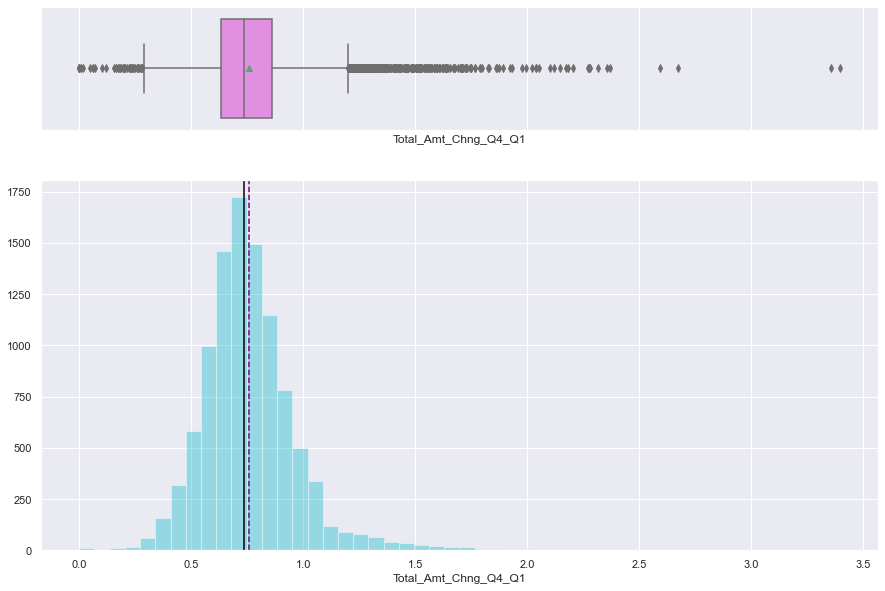

```python
histogram_boxplot(data['Total_Amt_Chng_Q4_Q1'])
```

- Total_Amt_Chng_Q4_Q1 is skewed to the right
- There are many outliers but we can keep them since they are close to each other and within Standard deviation

### Observations on Total_Trans_Amt

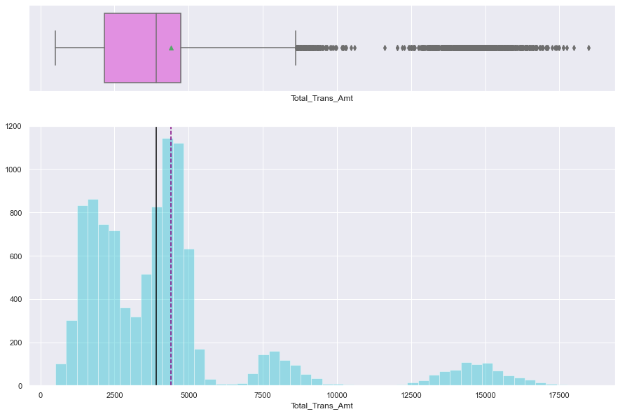

```python
histogram_boxplot(data['Total_Trans_Amt'])
```

- Total_Trans_Amt is skewed to right
- There are many outliers but we can keep them since they are close to each other and within Standard deviation

### Observations on Total_Trans_Ct

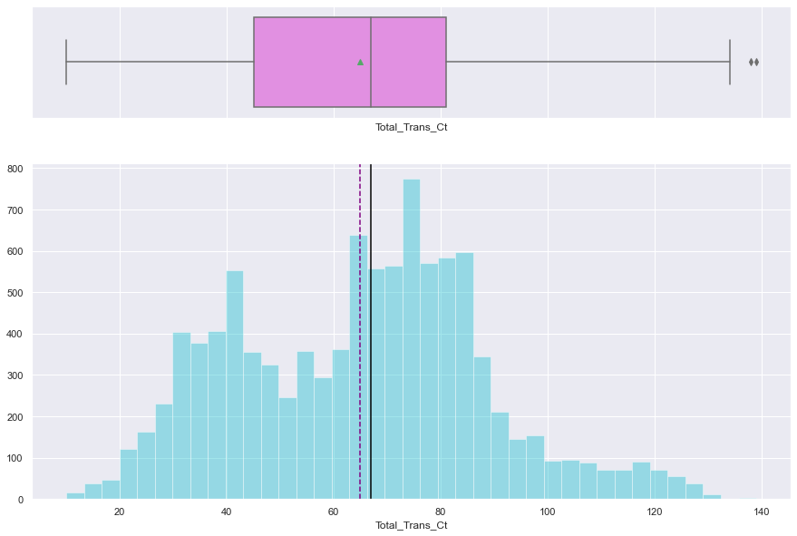

```python
histogram_boxplot(data['Total_Trans_Ct'])
```

- Total_Trans_Ct is sort of normally distributed but with 2 peaks
- there are 2 outliers but they are within range and within Standard deviation so we can keep them

### Observations on Total_Ct_Chng_Q4_Q1

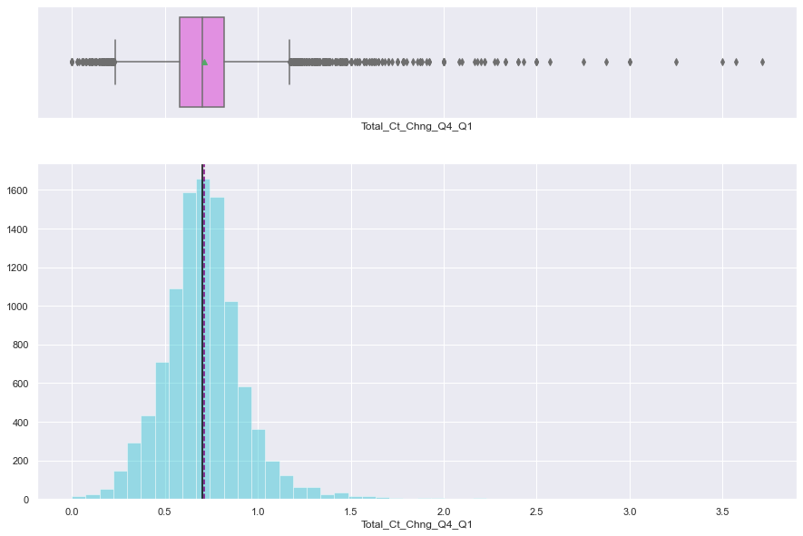

```python
histogram_boxplot(data['Total_Ct_Chng_Q4_Q1'])
```

- Total_Ct_Chng_Q4_Q1 is right skewed
- There are lot of outliers but they are close to each other and within Standard deviation so Ill keep them

### Observations on Avg_Utilization_Ratio

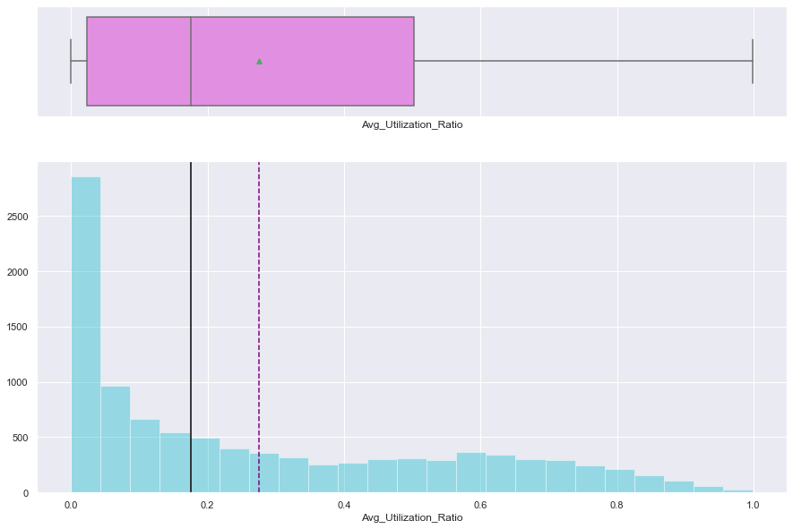

```python
histogram_boxplot(data['Avg_Utilization_Ratio'])
```

- Avg_Utilization_Ratio is right skewed
- there are no outliers

```python
# Function to create barplots that indicate percentage for each category.

def perc_on_bar(z):
    '''
    plot
    feature: categorical feature
    the function won't work if a column is passed in hue parameter
    '''

    total = len(data[z]) # length of the column
    plt.figure(figsize=(15,5))
    ax = sns.countplot(data[z],palette='Paired')
    for p in ax.patches:
        percentage = '{:.1f}%'.format(100 * p.get_height()/total) # percentage of each class of the category
        x = p.get_x() + p.get_width() / 2 - 0.05 # width of the plot
        y = p.get_y() + p.get_height()           # hieght of the plot

        ax.annotate(percentage, (x, y), size = 12) # annotate the percantage
    plt.show() # show the plot
```

### Observations on Attrition_Flag

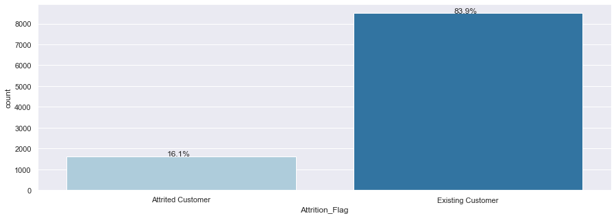

```python
perc_on_bar('Attrition_Flag')
```

- Existing customer has much more data than Attrited customer.need to be taken care while model building

### Observations on Contacts_Count_12_mon

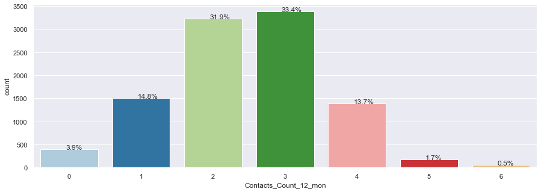

```python
perc_on_bar('Contacts_Count_12_mon')
```

- Customers contacted mostly 2 or 3 times followed by 1 and 4, very less 0,5 and 6 times

### Observations on Dependent_count

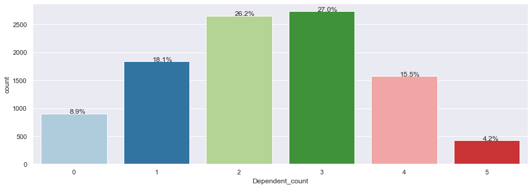

```python
perc_on_bar('Dependent_count')
```

- mostly there are 2 or 3 dependents

### Observations on Total_Relationship_Count

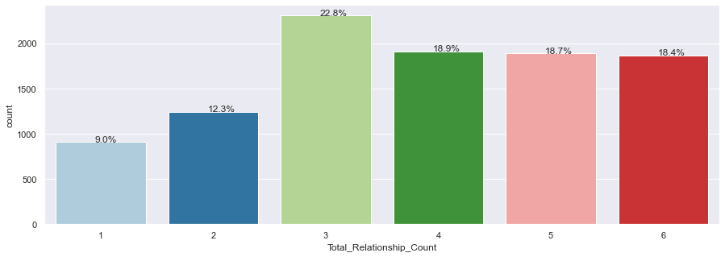

```python
perc_on_bar('Total_Relationship_Count')
```

- counts are almost equally distributed for 4,5,6 and maximum for 3

### Observations on Months_Inactive_12_mon

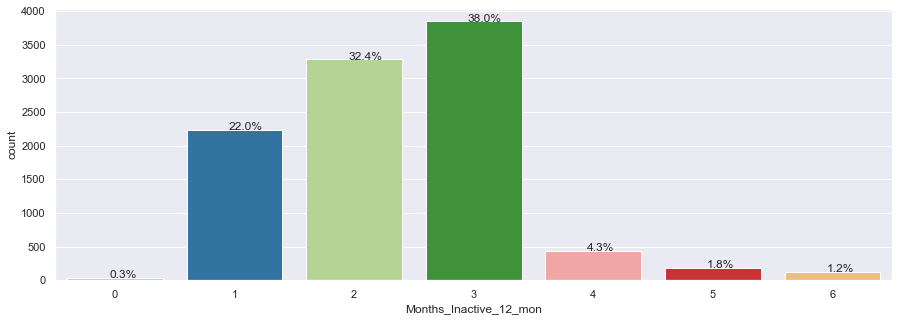

```python
perc_on_bar('Months_Inactive_12_mon')
```

- most customers were inactive for 2 or 3 months

### Observations on Gender

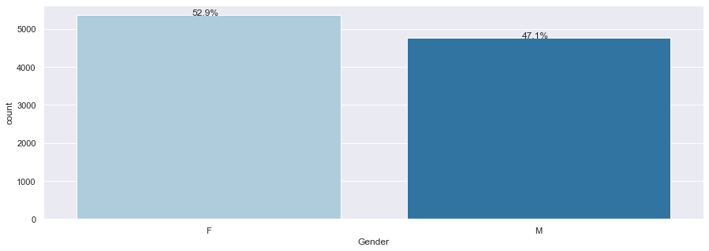

```python
perc_on_bar('Gender')
```

- More F than M by about 5%

### Observations on Education_Level

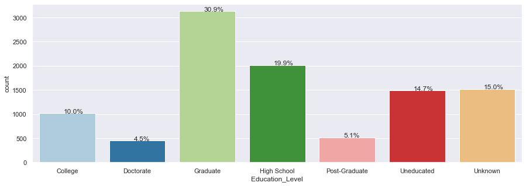

```python
perc_on_bar('Education_Level')
```

- Graduates have the highest number

### Observations on Marital_Status

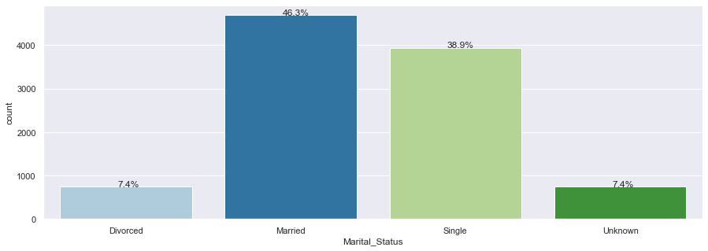

```python
perc_on_bar('Marital_Status')
```

- Married has the highest Marital Status

### Observations on Income_Category

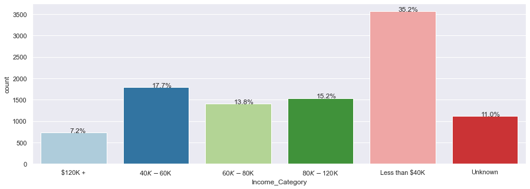

```python
perc_on_bar('Income_Category')
```

- Mostly people are in Less than $40k Income group

### Observations on Card_Category

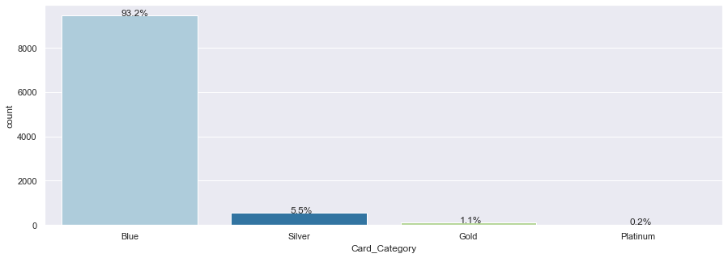

```python
perc_on_bar('Card_Category')
```

- Mostly customers have Blue card

# Bivariate Analysis

## Pairplot

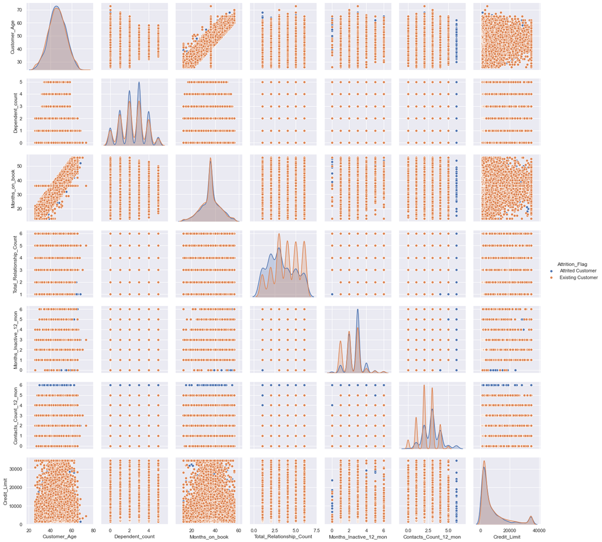

```python
sns.pairplot(data,x_vars=['Customer_Age',
'Dependent_count',
'Months_on_book',
'Total_Relationship_Count',
'Months_Inactive_12_mon',
'Contacts_Count_12_mon',
'Credit_Limit'],
 y_vars=[
'Customer_Age',
'Dependent_count',
'Months_on_book',
'Total_Relationship_Count',
'Months_Inactive_12_mon',
'Contacts_Count_12_mon',
'Credit_Limit',
] ,kind='scatter',diag_kind='kde',hue='Attrition_Flag'
)
plt.show()
```

- Months_on_book and customer_age seems to have a liner relationship

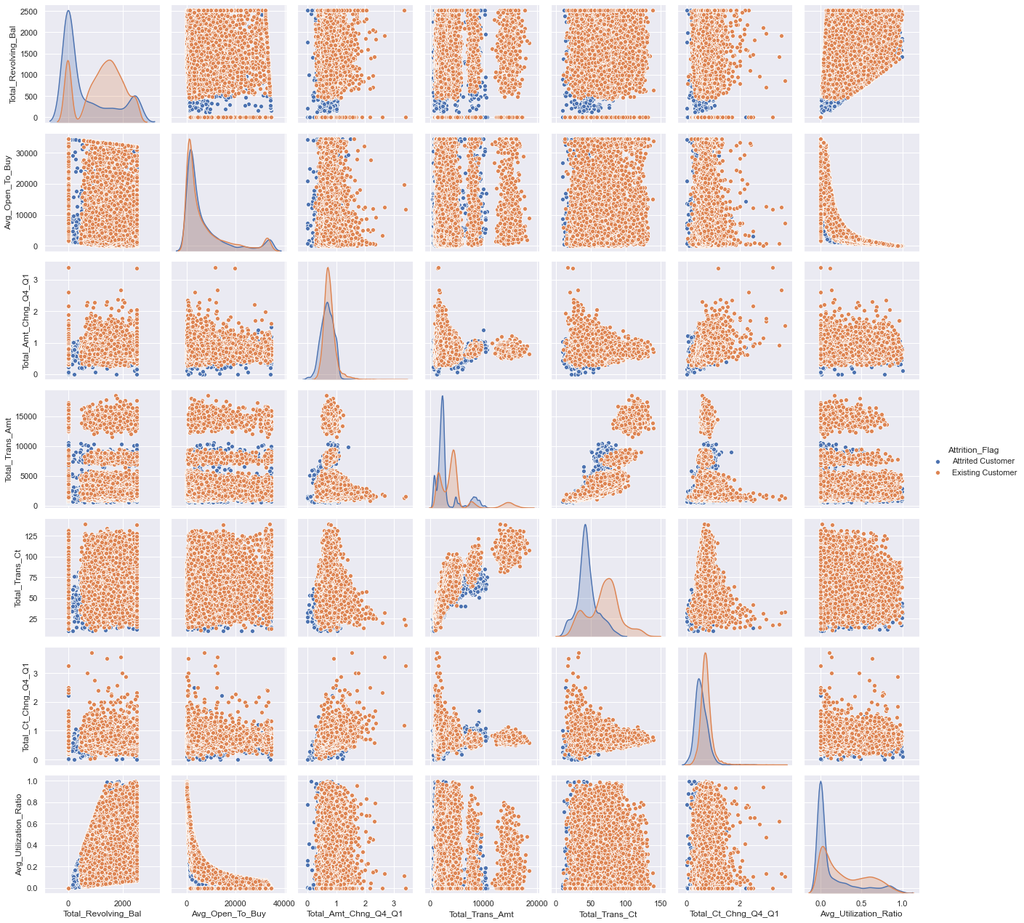

```python
sns.pairplot(data,x_vars=['Total_Revolving_Bal',
'Avg_Open_To_Buy',
'Total_Amt_Chng_Q4_Q1',
'Total_Trans_Amt',
'Total_Trans_Ct',
'Total_Ct_Chng_Q4_Q1',
'Avg_Utilization_Ratio'],
 y_vars=[
'Total_Revolving_Bal',
'Avg_Open_To_Buy',
'Total_Amt_Chng_Q4_Q1',
'Total_Trans_Amt',
'Total_Trans_Ct',
'Total_Ct_Chng_Q4_Q1',
'Avg_Utilization_Ratio'
] ,kind='scatter',diag_kind='kde',hue='Attrition_Flag'
)
plt.show()
```

- Avg_Open_To_Buy and Avg_Utilization_Ratio seems to have a quadratic relationship
- Total_Trans_ct and Total_trans_amt seems to have a sort of liner relationship
- Avg_utilization_ration and total_resolving_bal seems to have a liner relation
- other relationships are not so prominent

## Heatmap

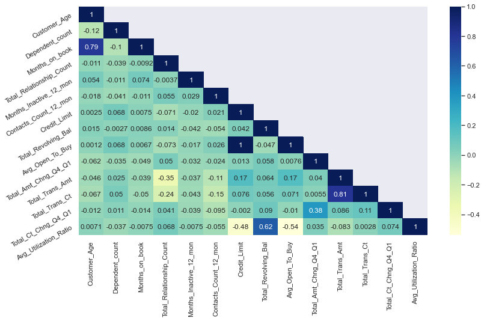

```python
corr = data.corr()
sns.set_context("notebook", font_scale=1.0, rc={"lines.linewidth": 2.5})
plt.figure(figsize=(13,7))
# create a mask so we only see the correlation values once
mask = np.zeros_like(corr)
mask[np.triu_indices_from(mask, 1)] = True
a = sns.heatmap(corr,mask=mask, annot=True,cmap="YlGnBu")
rotx = a.set_xticklabels(a.get_xticklabels(), rotation=90)
roty = a.set_yticklabels(a.get_yticklabels(), rotation=30)
```

- Credit_limit and Avg_open_to_buy seems to be fully corelated so we can drop 1.
- Total_trans_amt and total_trans_ct seems to be highly corelated and from description also looks similar, we can drop 1.
- months_on_book and customer_age seems corelated and logically also makes sense since someone who is associated with bank for longer period might have aged more during the period so we can drop it

```python
data.drop(['Avg_Open_To_Buy'],axis=1,inplace=True)
```

```python
data.drop(['Total_Trans_Ct'],axis=1,inplace=True)
```

```python
data.drop(['Months_on_book'],axis=1,inplace=True)
```

Encoding 1 and 0 to 'Attrited Customer' and 'Existing Customer' respectively, for analysis.

```python
data['Attrition_Flag'].replace('Attrited Customer',1,inplace=True)
data['Attrition_Flag'].replace('Existing Customer',0,inplace=True)
```

```python
### Function to plot stacked bar charts for categorical columns
def stacked_plot(x):
    sns.set()
    ## crosstab
    tab1 = pd.crosstab(x,data['Attrition_Flag'],margins=True).sort_values(by=1,ascending=False)
    print(tab1)
    print('-'*120)
    ## visualising the cross tab
    tab = pd.crosstab(x,data['Attrition_Flag'],normalize='index').sort_values(by=1,ascending=False)
    tab.plot(kind='bar',stacked=True,figsize=(17,7))
    plt.legend(loc='lower left', frameon=False)
    plt.legend(loc="upper left", bbox_to_anchor=(1,1))
    plt.show()
```

### Customer_Age vs Attrition_Flag

```
Attrition_Flag     1     0    All
Customer_Age
All             1627  8500  10127
43                85   388    473
48                85   387    472
44                84   416    500
46                82   408    490
45                79   407    486
49                79   416    495
47                76   403    479
41                76   303    379
50                71   381    452
54                69   238    307
40                64   297    361
42                62   364    426
```

[output cut: 34 more lines]

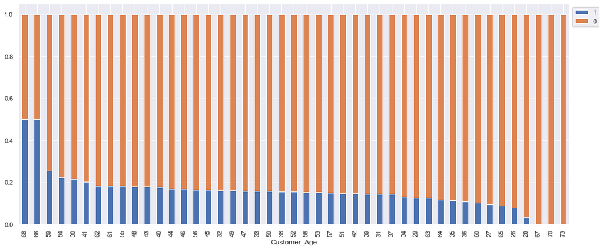

```python
stacked_plot(data['Customer_Age'])
```

### Gender vs Attrition_Flag

```
Attrition_Flag     1     0    All
Gender
All             1627  8500  10127
F                930  4428   5358
M                697  4072   4769
------------------------------------------------------------------------------------------------------------------------
```

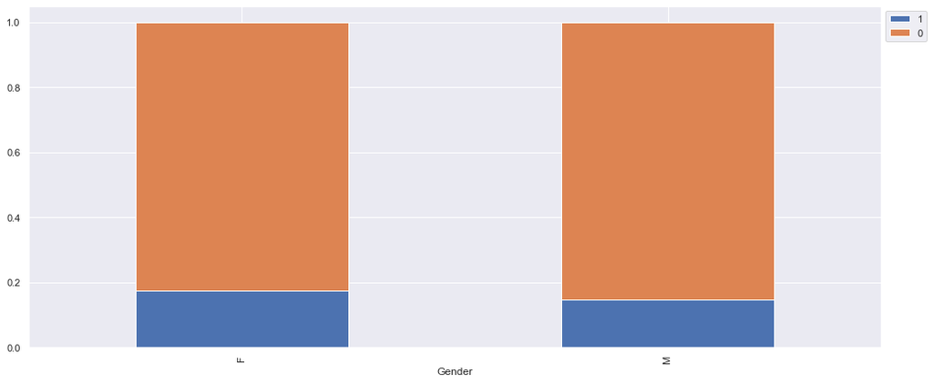

```python
stacked_plot(data['Gender'])
```

- Both looks almost same which suggests there is no relation between gender and attrition

### Dependent_count vs Attrition_Flag

```
Attrition_Flag      1     0    All
Dependent_count
All              1627  8500  10127
3                 482  2250   2732
2                 417  2238   2655
1                 269  1569   1838
4                 260  1314   1574
0                 135   769    904
5                  64   360    424
------------------------------------------------------------------------------------------------------------------------
```

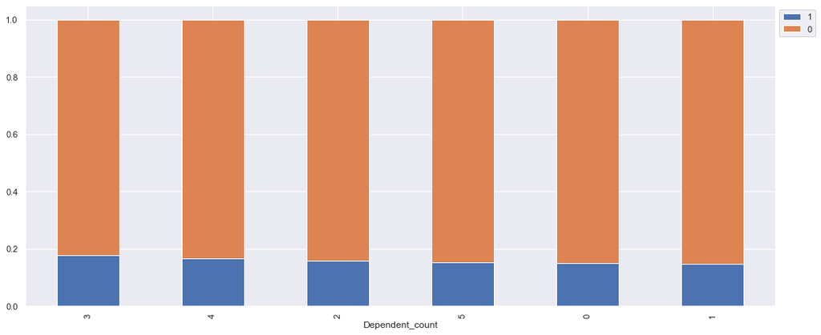

```python
stacked_plot(data['Dependent_count'])
```

- All categories looks almost same which suggests there is no relation between Dependent_count and attrition

### Education_Level vs Attrition_Flag

```
Attrition_Flag      1     0    All
Education_Level
All              1627  8500  10127
Graduate          487  2641   3128
High School       306  1707   2013
Unknown           256  1263   1519
Uneducated        237  1250   1487
College           154   859   1013
Doctorate          95   356    451
Post-Graduate      92   424    516
------------------------------------------------------------------------------------------------------------------------
```

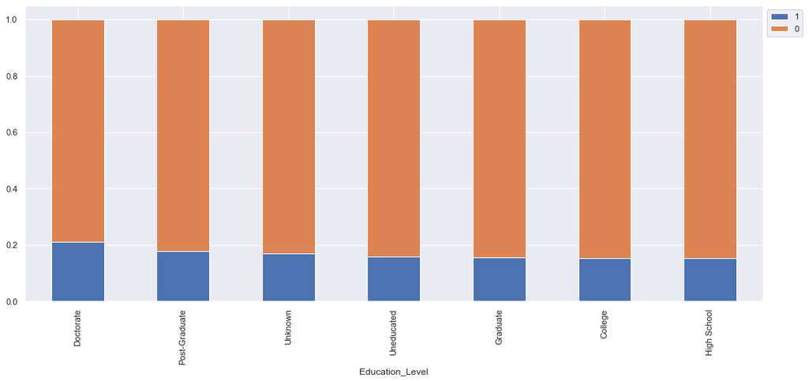

```python
stacked_plot(data['Education_Level'])
```

- Doctorate has a tad bit more attrition as compared to others

### Marital_Status vs Attrition_Flag

```
Attrition_Flag     1     0    All
Marital_Status
All             1627  8500  10127
Married          709  3978   4687
Single           668  3275   3943
Unknown          129   620    749
Divorced         121   627    748
------------------------------------------------------------------------------------------------------------------------
```

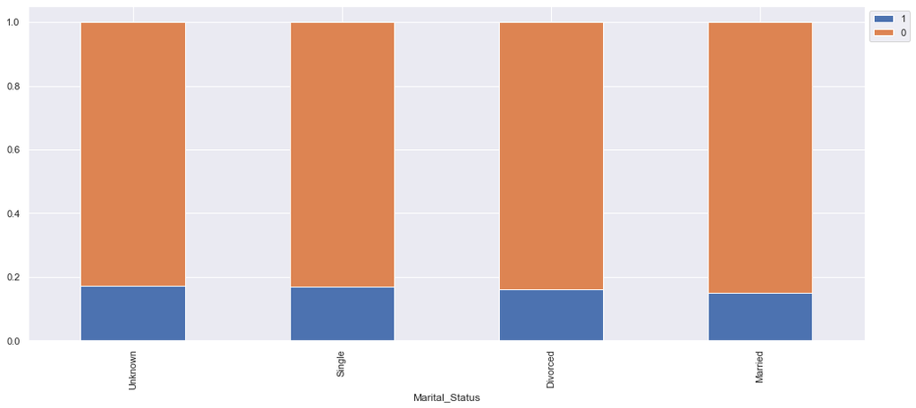

```python
stacked_plot(data['Marital_Status'])
```

- All categories looks almost same which suggests there is no relation between Marital_status and attrition

### Income_Category vs Attrition_Flag

```
Attrition_Flag      1     0    All
Income_Category
All              1627  8500  10127
Less than $40K    612  2949   3561
$40K - $60K       271  1519   1790
$80K - $120K      242  1293   1535
$60K - $80K       189  1213   1402
Unknown           187   925   1112
$120K +           126   601    727
------------------------------------------------------------------------------------------------------------------------
```

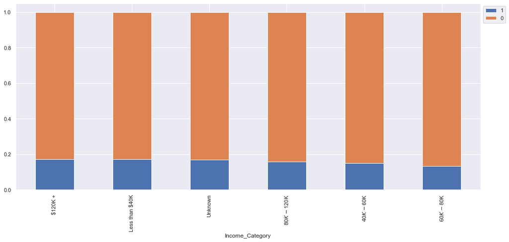

```python
stacked_plot(data['Income_Category'])
```

- $120K+ category has a little bit more attrition as compared to others

### Card_Category vs Attrition_Flag

```
Attrition_Flag     1     0    All
Card_Category
All             1627  8500  10127
Blue            1519  7917   9436
Silver            82   473    555
Gold              21    95    116
Platinum           5    15     20
------------------------------------------------------------------------------------------------------------------------
```

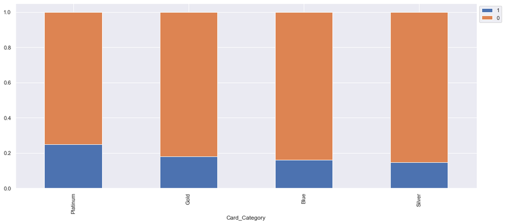

```python
stacked_plot(data['Card_Category'])
```

- Platinum seems to have highest attrition. Maybe something is wrong with that card_category like interest rate or something. needs to be investigated